# OP-USD

## OP-USD today is +0200, 2025-10-27, 21:18:00

This crypto forecast was generated by gemini-2.0-flash API

## Daily Chart

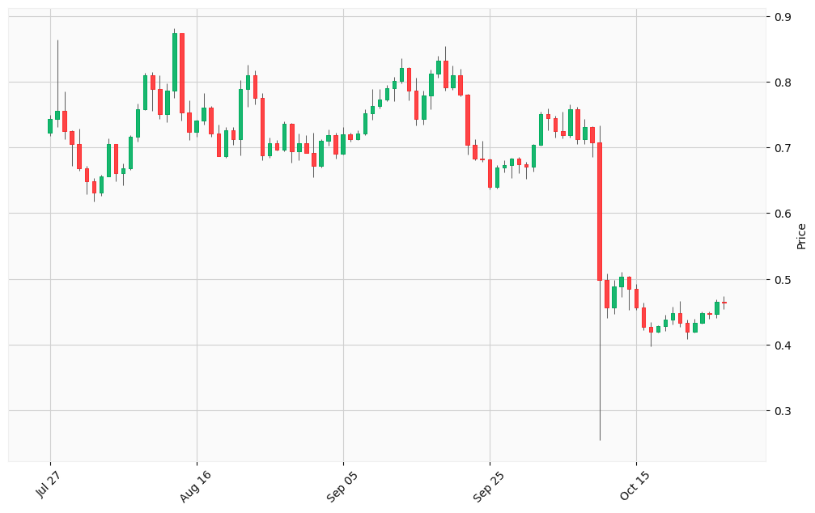

## Hourly Chart

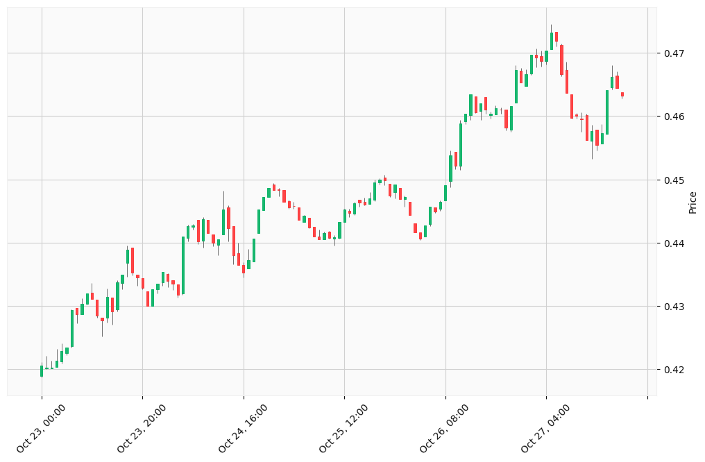

Here’s an analysis of the OP-USD cryptocurrency, combining technical data with market context, to generate trading signals.

### Market Data Collection & News and Economic Analysis

- **Current Market Trends:** The cryptocurrency market is showing overall growth, with a total market capitalization of $3.98 trillion.
- **OP-USD News:** Recent news indicates optimism surrounding potential US-China trade deals, which could positively influence investor sentiment.
- **Global Economy:** The global economy is projected to grow at 3.0% for 2025 and 3.1% in 2026.
- **Upcoming Token Unlock:** OP has an upcoming token unlock on October 31, which will release 31.34 million tokens, equivalent to 1.71% of the circulating supply. This could create selling pressure.

### Technical Analysis

First I will calculate Simple Moving Averages (SMA) and then Relative Strength Index (RSI) for the daily chart.

**Calculations for Daily Chart**

Here are the calculated 10-day and 20-day Simple Moving Averages (SMA), along with the 14-day Relative Strength Index (RSI) for the provided OP-USD daily chart data:

[output not shown]

**Calculations for Hourly Chart**

Here are the calculated 12-hour and 24-hour Simple Moving Averages (SMA), along with the 14-hour Relative Strength Index (RSI) for the provided OP-USD hourly chart data:

[output not shown]